# W3cubDocs

#### Methods

| `apply`(X) | Apply trees in the ensemble to X, return leaf indices. |
| --- | --- |
| `decision_function`(X) | Compute the decision function of `X`. |
| `fit`(X, y[, sample_weight, monitor]) | Fit the gradient boosting model. |
| `get_params`([deep]) | Get parameters for this estimator. |
| `predict`(X) | Predict class for X. |
| `predict_log_proba`(X) | Predict class log-probabilities for X. |
| `predict_proba`(X) | Predict class probabilities for X. |
| `score`(X, y[, sample_weight]) | Returns the mean accuracy on the given test data and labels. |
| `set_params`(**params) | Set the parameters of this estimator. |
| `staged_decision_function`(X) | Compute decision function of `X` for each iteration. |
| `staged_predict`(X) | Predict class at each stage for X. |
| `staged_predict_proba`(X) | Predict class probabilities at each stage for X. |

**`__init__(loss=’deviance’, learning_rate=0.1, n_estimators=100, subsample=1.0, criterion=’friedman_mse’, min_samples_split=2, min_samples_leaf=1, min_weight_fraction_leaf=0.0, max_depth=3, min_impurity_decrease=0.0, min_impurity_split=None, init=None, random_state=None, max_features=None, verbose=0, max_leaf_nodes=None, warm_start=False, presort=’auto’, validation_fraction=0.1, n_iter_no_change=None, tol=0.0001)` [[source]](https://github.com/scikit-learn/scikit-learn/blob/bac89c2/sklearn/ensemble/gradient_boosting.py#L1935)**

**`apply(X)` [[source]](https://github.com/scikit-learn/scikit-learn/blob/bac89c2/sklearn/ensemble/gradient_boosting.py#L1648)**

Apply trees in the ensemble to X, return leaf indices.

New in version 0.17.

[output not shown]

**`decision_function(X)` [[source]](https://github.com/scikit-learn/scikit-learn/blob/bac89c2/sklearn/ensemble/gradient_boosting.py#L1972)**

Compute the decision function of `X`.

[output not shown]

**`feature_importances_`**

feature).

| Returns: | **`feature_importances_ : array, shape (n_features,)`** |
| --- | --- |

**`fit(X, y, sample_weight=None, monitor=None)` [[source]](https://github.com/scikit-learn/scikit-learn/blob/bac89c2/sklearn/ensemble/gradient_boosting.py#L1355)**

Fit the gradient boosting model.

[output not shown]

**`get_params(deep=True)` [[source]](https://github.com/scikit-learn/scikit-learn/blob/bac89c2/sklearn/base.py#L166)**

Get parameters for this estimator.

| Parameters: | **`deep : boolean, optional`** If True, will return the parameters for this estimator and contained subobjects that are estimators. |
| --- | --- |
| Returns: | **`params : mapping of string to any`** Parameter names mapped to their values. |

**`n_features`**

DEPRECATED: Attribute n_features was deprecated in version 0.19 and will be removed in 0.21.

**`predict(X)` [[source]](https://github.com/scikit-learn/scikit-learn/blob/bac89c2/sklearn/ensemble/gradient_boosting.py#L2021)**

Predict class for X.

[output not shown]

**`predict_log_proba(X)` [[source]](https://github.com/scikit-learn/scikit-learn/blob/bac89c2/sklearn/ensemble/gradient_boosting.py#L2092)**

Predict class log-probabilities for X.

[output not shown]

**`predict_proba(X)` [[source]](https://github.com/scikit-learn/scikit-learn/blob/bac89c2/sklearn/ensemble/gradient_boosting.py#L2062)**

Predict class probabilities for X.

[output not shown]

**`score(X, y, sample_weight=None)` [[source]](https://github.com/scikit-learn/scikit-learn/blob/bac89c2/sklearn/base.py#L263)**

Returns the mean accuracy on the given test data and labels.

In multi-label classification, this is the subset accuracy which is a harsh metric since you require for each sample that each label set be correctly predicted.

[output not shown]

**`set_params(**params)` [[source]](https://github.com/scikit-learn/scikit-learn/blob/bac89c2/sklearn/base.py#L189)**

Set the parameters of this estimator.

The method works on simple estimators as well as on nested objects (such as pipelines). The latter have parameters of the form `<component>__<parameter>` so that it’s possible to update each component of a nested object.

| Returns: | **self** |
| --- | --- |

**`staged_decision_function(X)` [[source]](https://github.com/scikit-learn/scikit-learn/blob/bac89c2/sklearn/ensemble/gradient_boosting.py#L1996)**

Compute decision function of `X` for each iteration.

This method allows monitoring (i.e. determine error on testing set) after each stage.

[output not shown]

**`staged_predict(X)` [[source]](https://github.com/scikit-learn/scikit-learn/blob/bac89c2/sklearn/ensemble/gradient_boosting.py#L2040)**

Predict class at each stage for X.

This method allows monitoring (i.e. determine error on testing set) after each stage.

[output not shown]

**`staged_predict_proba(X)` [[source]](https://github.com/scikit-learn/scikit-learn/blob/bac89c2/sklearn/ensemble/gradient_boosting.py#L2116)**

Predict class probabilities at each stage for X.

This method allows monitoring (i.e. determine error on testing set) after each stage.

[output not shown]

## 3.2.4.3.5.1. Examples using `sklearn.ensemble.GradientBoostingClassifier`

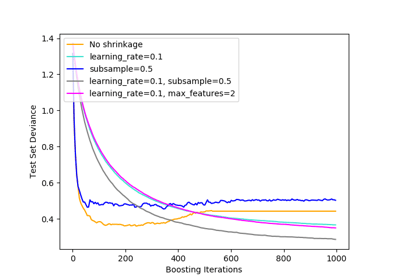

Gradient Boosting regularization

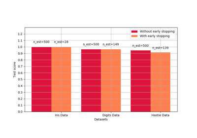

Early stopping of Gradient Boosting

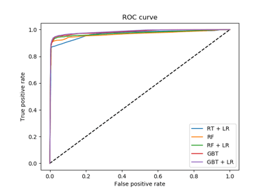

Feature transformations with ensembles of trees

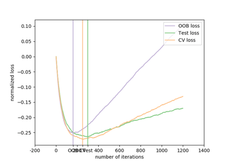

Gradient Boosting Out-of-Bag estimates